# STATS 101A Project EDA

```r
## Loading the data
library(dplyr)
data <- read.csv('revised_dataset.csv')
data <- tibble(data) %>% select(acceptance_rate, name, sat_avg, hs_gpa_avg, enrollment, public_private) %>% mutate(public_private = case_when(public_private == "private" ~ 1, public_private == "public" ~ 0))
attach(data)
data
```

| acceptance_rate | name | sat_avg | hs_gpa_avg | enrollment | public_private |
| --- | --- | --- | --- | --- | --- |
| 67 | Seton Hall University | 1070 | 3.60 | 5956 | 1 |
| 69 | University of Vermont | 1100 | 3.60 | 11159 | 0 |
| 66 | Texas A&M University--College Station | 1070 | 3.68 | 50735 | 0 |
| 71 | University of Oklahoma | 1060 | 3.60 | 22436 | 0 |
| 66 | Michigan State University | 990 | 3.70 | 39090 | 0 |
| 66 | University of California--Riverside | 940 | 3.70 | 19799 | 0 |
| 68 | University of South Carolina | 1120 | 3.69 | 25556 | 0 |
| 76 | University of Utah | 1050 | 3.60 | 23789 | 0 |
| 76 | University of Cincinnati | 1030 | 3.60 | 25860 | 0 |
| 78 | University of Oregon | 980 | 3.60 | 20049 | 0 |

[output cut: 206 more lines]

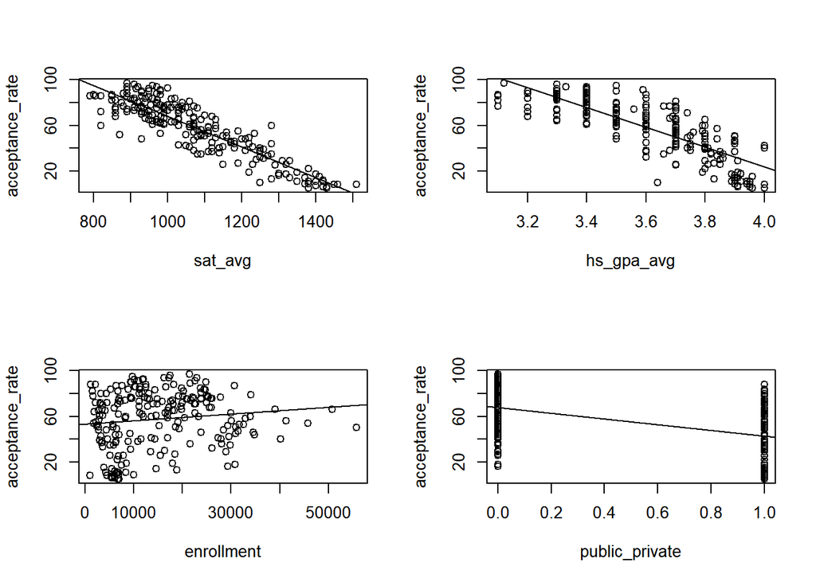

```r
## Single Variable Relationships, Correlations

par(mfrow = c(2, 2))
plot(sat_avg, acceptance_rate)
abline(lm(acceptance_rate ~ sat_avg))
plot(hs_gpa_avg, acceptance_rate)
abline(lm(acceptance_rate ~ hs_gpa_avg))
plot(enrollment, acceptance_rate)
abline(lm(acceptance_rate ~ enrollment))
plot(public_private, acceptance_rate)
abline(lm(acceptance_rate ~ public_private))
```

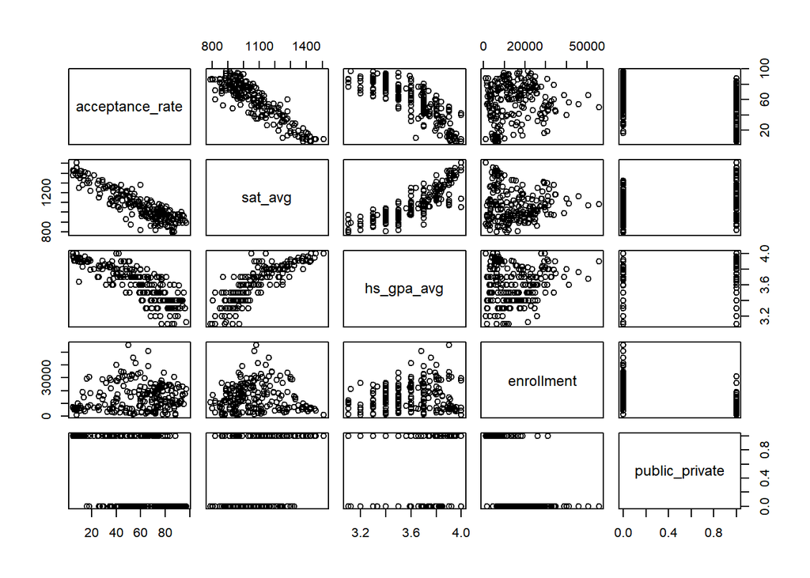

```r
pairs(data %>% select(acceptance_rate, sat_avg, hs_gpa_avg, enrollment, public_private))
```

```r
cor(data %>% select(acceptance_rate, sat_avg, hs_gpa_avg, enrollment, public_private))
```

```
##                 acceptance_rate     sat_avg hs_gpa_avg  enrollment
## acceptance_rate       1.0000000 -0.89475093 -0.8125129  0.12438424
## sat_avg              -0.8947509  1.00000000  0.8434822 -0.06562565
## hs_gpa_avg           -0.8125129  0.84348217  1.0000000  0.12047118
## enrollment            0.1243842 -0.06562565  0.1204712  1.00000000
## public_private       -0.4957500  0.43636409  0.3092901 -0.63270822
##                 public_private
## acceptance_rate     -0.4957500
## sat_avg              0.4363641
## hs_gpa_avg           0.3092901
## enrollment          -0.6327082
## public_private       1.0000000
```

```r
##VIF
```

```r
## Untransformed and Unreduced Model

m1 <- lm(acceptance_rate ~ sat_avg + hs_gpa_avg + enrollment + public_private)
summary(m1)
```

```
##
## Call:
## lm(formula = acceptance_rate ~ sat_avg + hs_gpa_avg + enrollment +
##     public_private)
##
## Residuals:
##     Min      1Q  Median      3Q     Max
## -27.067  -7.079  -0.342   7.830  23.988
##
## Coefficients:
##                  Estimate Std. Error t value Pr(>|t|)
## (Intercept)     2.570e+02  1.468e+01  17.506  < 2e-16 ***
## sat_avg        -9.523e-02  8.537e-03 -11.155  < 2e-16 ***
## hs_gpa_avg     -2.653e+01  6.070e+00  -4.371 1.94e-05 ***
## enrollment      8.583e-05  9.698e-05   0.885  0.37716
## public_private -6.093e+00  2.168e+00  -2.810  0.00542 **
## ---
## Signif. codes:  0 '***' 0.001 '**' 0.01 '*' 0.05 '.' 0.1 ' ' 1
##
## Residual standard error: 10.26 on 211 degrees of freedom
## Multiple R-squared:   0.83,  Adjusted R-squared:  0.8268
## F-statistic: 257.5 on 4 and 211 DF,  p-value: < 2.2e-16
```

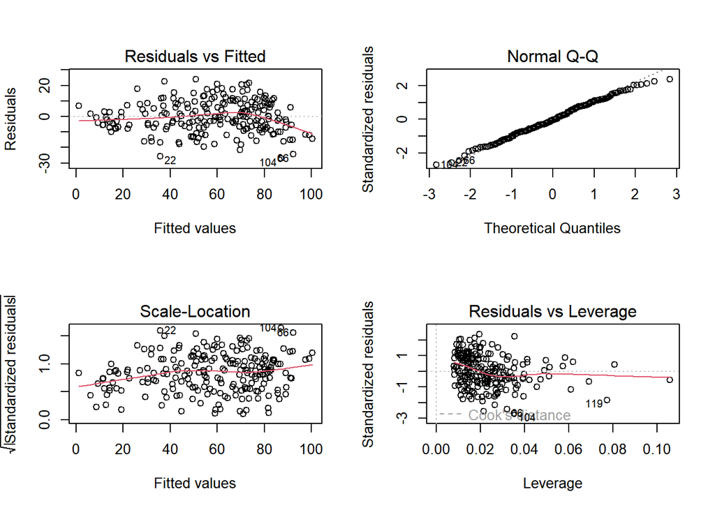

```r
par(mfrow = c(2, 2))
plot(m1)
```

```r
## Transformed Model (don't include categorical variable public/private)

library(car)
tranxy <- powerTransform(cbind(acceptance_rate, sat_avg, hs_gpa_avg, enrollment) ~ 1)

summary(tranxy)
```

```
## bcPower Transformations to Multinormality
##                 Est Power Rounded Pwr Wald Lwr Bnd Wald Upr Bnd
## acceptance_rate    1.0017        1.00       0.8275       1.1758
## sat_avg            0.2323        0.00      -0.3938       0.8585
## hs_gpa_avg         5.1274        5.13       3.5475       6.7073
## enrollment         0.3559        0.50       0.1988       0.5131
##
## Likelihood ratio test that transformation parameters are equal to 0
##  (all log transformations)
##                                  LRT df       pval
## LR test, lambda = (0 0 0 0) 249.9157  4 < 2.22e-16
##
## Likelihood ratio test that no transformations are needed
##                                 LRT df       pval
## LR test, lambda = (1 1 1 1) 96.6896  4 < 2.22e-16
```

```r
m2 <- lm(acceptance_rate ~ sat_avg + I(hs_gpa_avg^5) + public_private + enrollment)

summary(m2)
```

```
##
## Call:
## lm(formula = acceptance_rate ~ sat_avg + I(hs_gpa_avg^5) + public_private +
##     enrollment)
##
## Residuals:
##      Min       1Q   Median       3Q      Max
## -28.0167  -6.7305  -0.6803   7.6850  23.8480
##
## Coefficients:
##                   Estimate Std. Error t value Pr(>|t|)
## (Intercept)      1.766e+02  6.143e+00  28.750  < 2e-16 ***
## sat_avg         -8.618e-02  8.916e-03  -9.666  < 2e-16 ***
## I(hs_gpa_avg^5) -3.964e-02  7.508e-03  -5.279 3.22e-07 ***
## public_private  -6.125e+00  2.121e+00  -2.888  0.00429 **
## enrollment       9.329e-05  9.404e-05   0.992  0.32232
## ---
## Signif. codes:  0 '***' 0.001 '**' 0.01 '*' 0.05 '.' 0.1 ' ' 1
##
## Residual standard error: 10.07 on 211 degrees of freedom
## Multiple R-squared:  0.8362, Adjusted R-squared:  0.8331
## F-statistic: 269.3 on 4 and 211 DF,  p-value: < 2.2e-16
```

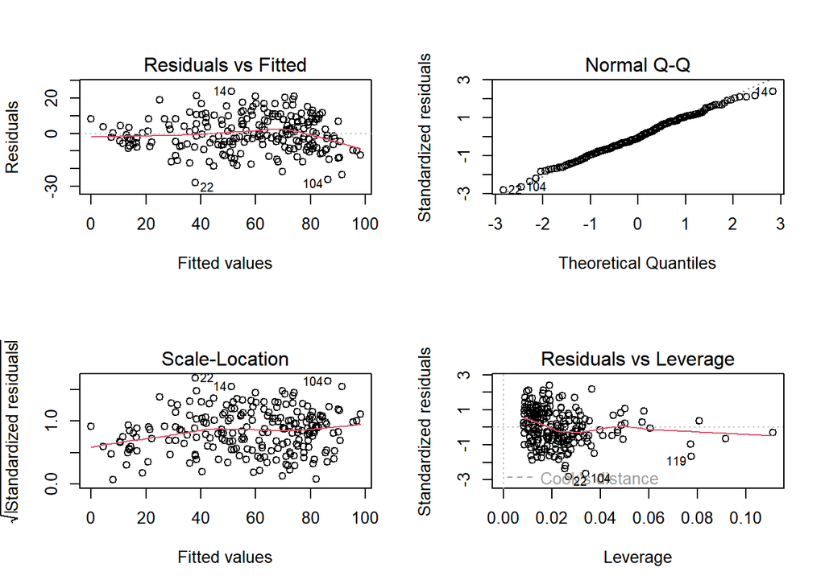

```r
par(mfrow = c(2, 2))
plot(m2)
```

```r
## Transforming sat_avg to log(sat_avg) makes our R^2 and diagnostics a bit worse, so the only variable we will transform is hs_gpa_avg to (hs_gpa_avg)^5
```

```r
## Variable Reduction

## No multicollinearity issues, since all VIFs are less than 5.
vif(m2)
```

```
##         sat_avg I(hs_gpa_avg^5)  public_private      enrollment
##        4.498801        4.432735        2.288202        2.018236
```

```r
## Forward Step and Backward Elmination with AIC or BIC: Include all but enrollment (as we expected)

step(lm(acceptance_rate ~ 1), acceptance_rate ~ sat_avg + I(hs_gpa_avg^5) + public_private + enrollment, k = log(nrow(data)))
```

```
## Start:  AIC=1388.75
## acceptance_rate ~ 1
##
##                   Df Sum of Sq    RSS    AIC
## + sat_avg          1    104547  26042 1045.9
## + I(hs_gpa_avg^5)  1     91991  38598 1130.9
## + public_private   1     32095  98495 1333.2
## <none>                         130589 1388.8
## + enrollment       1      2020 128569 1390.8
##
## Step:  AIC=1045.86
## acceptance_rate ~ sat_avg
##
##                   Df Sum of Sq    RSS    AIC
## + I(hs_gpa_avg^5)  1      2216  23826 1032.0
## + public_private   1      1789  24253 1035.9
## <none>                          26042 1045.9
## + enrollment       1       566  25477 1046.5
## - sat_avg          1    104547 130589 1388.8
##
## Step:  AIC=1032.03
## acceptance_rate ~ sat_avg + I(hs_gpa_avg^5)
##
##                   Df Sum of Sq   RSS    AIC
## + public_private   1    2338.0 21488 1015.1
## + enrollment       1    1592.5 22234 1022.5
## <none>                         23826 1032.0
## - I(hs_gpa_avg^5)  1    2215.9 26042 1045.9
## - sat_avg          1   14771.5 38598 1130.9
##
## Step:  AIC=1015.1
## acceptance_rate ~ sat_avg + I(hs_gpa_avg^5) + public_private
##
##                   Df Sum of Sq   RSS    AIC
## <none>                         21488 1015.1
## + enrollment       1      99.8 21389 1019.5
## - public_private   1    2338.0 23826 1032.0
## - I(hs_gpa_avg^5)  1    2765.0 24253 1035.9
## - sat_avg          1    9739.2 31228 1090.5
```

```
##
## Call:
## lm(formula = acceptance_rate ~ sat_avg + I(hs_gpa_avg^5) + public_private)
##
## Coefficients:
##     (Intercept)          sat_avg  I(hs_gpa_avg^5)   public_private
##       178.02956         -0.08701         -0.03739         -7.54023
```

```r
#step(lm(acceptance_rate ~ 1), acceptance_rate ~ sat_avg + I(hs_gpa_avg^5) + public_private + enrollment, k = log(nrow(data)))

step(lm(acceptance_rate ~ sat_avg + I(hs_gpa_avg^5) + public_private + enrollment), acceptance_rate ~ sat_avg + I(hs_gpa_avg^5) + public_private + enrollment)
```

```
## Start:  AIC=1002.59
## acceptance_rate ~ sat_avg + I(hs_gpa_avg^5) + public_private +
##     enrollment
##
##                   Df Sum of Sq   RSS    AIC
## - enrollment       1      99.8 21488 1001.6
## <none>                         21389 1002.6
## - public_private   1     845.3 22234 1009.0
## - I(hs_gpa_avg^5)  1    2824.8 24213 1027.4
## - sat_avg          1    9471.8 30860 1079.8
##
## Step:  AIC=1001.6
## acceptance_rate ~ sat_avg + I(hs_gpa_avg^5) + public_private
##
##                   Df Sum of Sq   RSS    AIC
## <none>                         21488 1001.6
## + enrollment       1      99.8 21389 1002.6
## - public_private   1    2338.0 23826 1021.9
## - I(hs_gpa_avg^5)  1    2765.0 24253 1025.7
## - sat_avg          1    9739.2 31228 1080.3
```

```
##
## Call:
## lm(formula = acceptance_rate ~ sat_avg + I(hs_gpa_avg^5) + public_private)
##
## Coefficients:
##     (Intercept)          sat_avg  I(hs_gpa_avg^5)   public_private
##       178.02956         -0.08701         -0.03739         -7.54023
```

```r
#step(lm(acceptance_rate ~ sat_avg + I(hs_gpa_avg^5) + public_private + enrollment), acceptance_rate ~ sat_avg + I(hs_gpa_avg^5) + public_private + enrollment, k = log(nrow(data)))
```

```r
#Final Model
final_model <- lm(acceptance_rate ~ sat_avg + I(hs_gpa_avg^5) + public_private)
summary(final_model)
```

```
##
## Call:
## lm(formula = acceptance_rate ~ sat_avg + I(hs_gpa_avg^5) + public_private)
##
## Residuals:
##      Min       1Q   Median       3Q      Max
## -27.8329  -6.9711  -0.6892   7.4151  24.4105
##
## Coefficients:
##                   Estimate Std. Error t value Pr(>|t|)
## (Intercept)     178.029556   5.972222  29.810  < 2e-16 ***
## sat_avg          -0.087011   0.008877  -9.802  < 2e-16 ***
## I(hs_gpa_avg^5)  -0.037391   0.007159  -5.223 4.20e-07 ***
## public_private   -7.540226   1.569971  -4.803 2.96e-06 ***
## ---
## Signif. codes:  0 '***' 0.001 '**' 0.01 '*' 0.05 '.' 0.1 ' ' 1
##
## Residual standard error: 10.07 on 212 degrees of freedom
## Multiple R-squared:  0.8355, Adjusted R-squared:  0.8331
## F-statistic: 358.8 on 3 and 212 DF,  p-value: < 2.2e-16
```

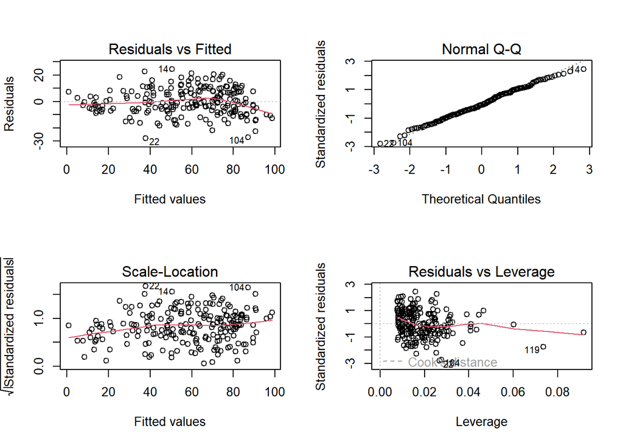

```r
par(mfrow = c(2, 2))
plot(final_model)
```

Model Assessment

R^2 and p-values are all great, and coefficients make intuitive sense. Diagnostic plots are pretty good - appears to be normally distributed. Only one bad leverage point (119) which is a small private school (Gardner-Webb University) with a pretty high average GPA and a higher acceptance rate. There is a bit of nonlinearity present that we can see on the far right of the residuals vs fitted plot. This is likely because we don’t have many colleges in our dataset that have near a 100% acceptance rate, as those colleges usually don’t report average GPA and test scores.

Interpretations: SAT SCORE

For every one point increase in SAT score, the acceptance rate tends to decrease by 0.087%. This makes sense because higher average test scores should be associated with a lower acceptance rate. Additionally, this number is very small because a one point change in an SAT score (which is out of 1600) is very small.

HIGH SCHOOL GPA

Difficult to interpret directly, since we transformed the variable. However, the negative coefficient shows that an increase in average high school gpa also leads to a decrease in acceptance rate.

PUBLIC/PRIVATE

With all else held equal, a private school tends to have a 7.54% lower acceptance rate than a public school. This could be partially affected by the fact that our dataset doesn’t include many state public schools that have high acceptance rates.